# STOR 565 Exploratory data analysis

02/28/2023

# Prostate cancer data

We take will use the prostate cancer (from the book [The Elements of Statistical Learning](http://statweb.stanford.edu/~tibs/ElemStatLearn/)) in this example. The measured variables:

- `lpsa`: log PSA (prostate-specific antigen) score
- `lcavol`: log cancer volume
- `lweight`: log prostate weight
- `age`: age of patient
- `lbph`: log of the amount of benign prostatic hyperplasia
- `svi`: seminal vesicle invasion
- `lcp`: log of capsular penetration
- `gleason`: Gleason score
- `pgg45`: percent of Gleason scores 4 or 5

```r
pros.df = read.table("pros.dat")

dim(pros.df)
```

```
## [1] 97  9
```

```r
head(pros.df)
```

```
##       lcavol  lweight age      lbph svi       lcp gleason pgg45       lpsa
## 1 -0.5798185 2.769459  50 -1.386294   0 -1.386294       6     0 -0.4307829
## 2 -0.9942523 3.319626  58 -1.386294   0 -1.386294       6     0 -0.1625189
## 3 -0.5108256 2.691243  74 -1.386294   0 -1.386294       7    20 -0.1625189
## 4 -1.2039728 3.282789  58 -1.386294   0 -1.386294       6     0 -0.1625189
## 5  0.7514161 3.432373  62 -1.386294   0 -1.386294       6     0  0.3715636
## 6 -1.0498221 3.228826  50 -1.386294   0 -1.386294       6     0  0.7654678
```

Some example questions we might be interested in:

- What is the relationship between `lcavol` and `lweight`?
- What is the relationship between `svi` and `lcavol`, `lweight`?
- Can we predict `lpsa` from the other variables?
- Can we predict whether `lpsa` is high or low, from other variables?

# Exploratory data analysis

“Torture the data, and it will confess to anything.” — Ronald Coase

Before pursuing a specific model, it’s generally a good idea to look at your data. When done in a structured way, this is called **exploratory data analysis** (EDA). In a nutshell, EDA is the process of summarizing important characteristics of data in order to gain better understanding of the dataset.

E.g., you might investigate:

- What are the distributions of the variables?
- Are there distinct subgroups of samples?
- Are there any noticeable outliers?
- Are there interesting relationship/trends to model?

# Distributions of prostate cancer variables

```r
colnames(pros.df) # These are the variables
```

```
## [1] "lcavol"  "lweight" "age"     "lbph"    "svi"     "lcp"     "gleason"
## [8] "pgg45"   "lpsa"
```

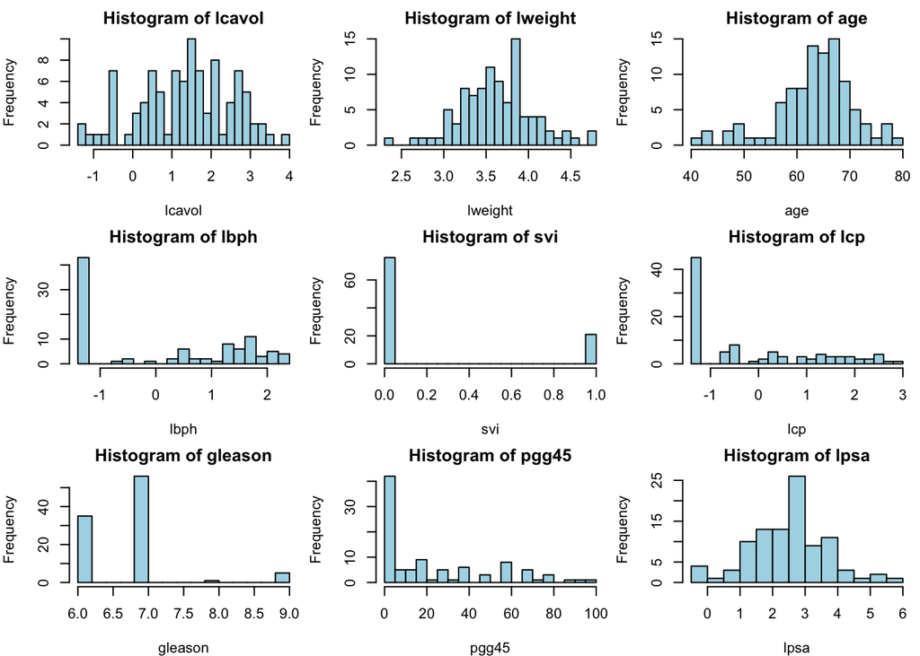

```r
par(mfrow=c(3,3), mar=c(4,4,2,0.5)) # Setup grid, margins
for (j in 1:ncol(pros.df)) {
  hist(pros.df[,j], xlab=colnames(pros.df)[j],
       main=paste("Histogram of", colnames(pros.df)[j]),
       col="lightblue", breaks=20)
}
```

What did we learn? A bunch of things! E.g.,

- `svi`, the presence of seminal vesicle invasion, is binary
- `lcp`, the log amount of capsular penetration, is very skewed, a bunch of men with little (or none?), then a big spread.
- `gleason`, takes integer values of 6 and larger; how does it relate to `pgg45`, the percentage of Gleason scores 4 or 5?
- `lpsa`, the log PSA score, is close-ish to normally distributed

After reading more and asking our doctor friends some questions, we learn:

- When the actual capsular penetration is very small, it can’t be properly measured, so it just gets arbitrarily set to 0.25 (and we can check that `min(pros.df$lcp)` $\approx \log{0.25}$)
- The variable `pgg45` measures the percentage of 4 or 5 Gleason scores that were recorded over their visit history *before* their final current Gleason score, stored in `gleason`; a higher Gleason score is worse, so `pgg45` tells us something about the severity of their cancer in the past

# Correlations between prostate cancer variables

```r
pros.cor = cor(pros.df)
round(pros.cor,3)
```

```
##         lcavol lweight   age   lbph    svi    lcp gleason pgg45  lpsa
## lcavol   1.000   0.281 0.225  0.027  0.539  0.675   0.432 0.434 0.734
## lweight  0.281   1.000 0.348  0.442  0.155  0.165   0.057 0.107 0.433
## age      0.225   0.348 1.000  0.350  0.118  0.128   0.269 0.276 0.170
## lbph     0.027   0.442 0.350  1.000 -0.086 -0.007   0.078 0.078 0.180
## svi      0.539   0.155 0.118 -0.086  1.000  0.673   0.320 0.458 0.566
## lcp      0.675   0.165 0.128 -0.007  0.673  1.000   0.515 0.632 0.549
## gleason  0.432   0.057 0.269  0.078  0.320  0.515   1.000 0.752 0.369
## pgg45    0.434   0.107 0.276  0.078  0.458  0.632   0.752 1.000 0.422
## lpsa     0.734   0.433 0.170  0.180  0.566  0.549   0.369 0.422 1.000
```

Some strong correlations! Let’s find the biggest (in absolute value):

```r
pros.cor[lower.tri(pros.cor,diag=TRUE)] = 0 # Why only upper tri part?
pros.cor.sorted = sort(abs(pros.cor),decreasing=T)
pros.cor.sorted[1]
```

```
## [1] 0.7519045
```

```r
vars.big.cor = arrayInd(which(abs(pros.cor)==pros.cor.sorted[1]),
                        dim(pros.cor)) # Note: arrayInd() is useful
colnames(pros.df)[vars.big.cor]
```

```
## [1] "gleason" "pgg45"
```

This is not surprising, given what we know about `pgg45` and `gleason`; essentially this is saying: if their Gleason score is high now, then they likely had a bad history of Gleason scores

Let’s find the second biggest correlation (in absolute value):

```r
pros.cor.sorted[2]
```

```
## [1] 0.7344603
```

```r
vars.big.cor = arrayInd(which(abs(pros.cor)==pros.cor.sorted[2]),
                        dim(pros.cor))
colnames(pros.df)[vars.big.cor]
```

```
## [1] "lcavol" "lpsa"
```

This is more interesting! If we wanted to predict `lpsa` from the other variables, then it seems like we should at least include `lcavol` as a predictor

# Visualizing relationships among variables, with `pairs()`

Can easily look at multiple scatter plots at once, using the `pairs()` function. The first argument is written like a **formula**, with no response variable. We’ll hold off on describing more about formulas until we learn `lm()`, shortly

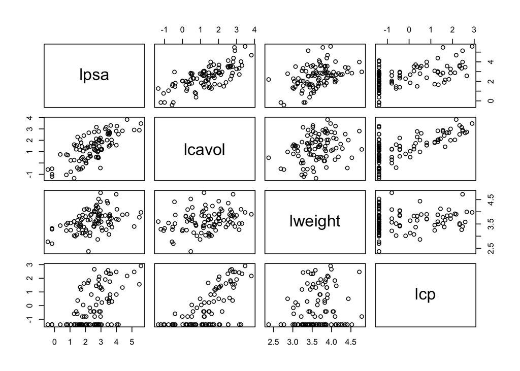

```r
pairs(~ lpsa + lcavol + lweight + lcp, data=pros.df)
```

# Inspecting relationships over a subset of the observations

As we’ve seen, the `lcp` takes a bunch of really low values, that don’t appear to have strong relationships with other variables. Let’s get rid of them and see what the relationships look like

```r
pros.df.subset = pros.df[pros.df$lcp > min(pros.df$lcp),] #how to do this using subset?
nrow(pros.df.subset) # Beware, we've lost a half of our data!
```

```
## [1] 52
```

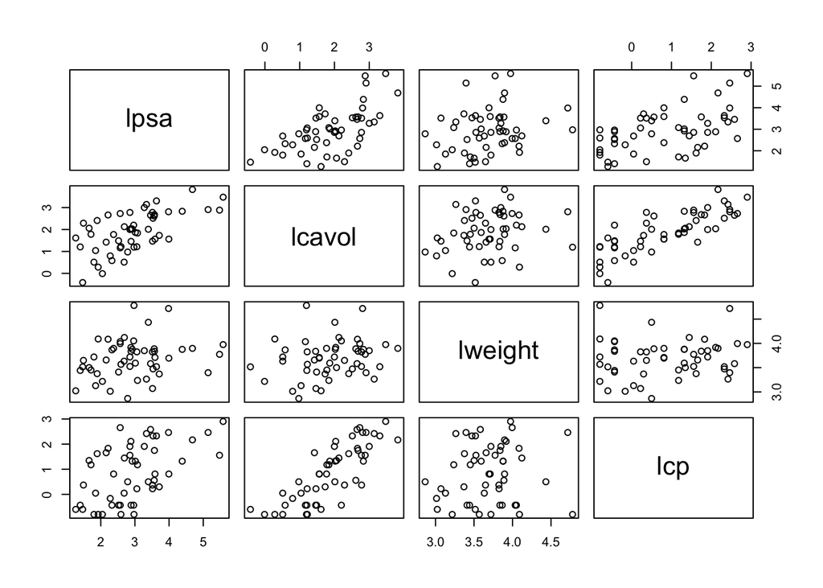

```r
pairs(~ lpsa + lcavol + lweight + lcp, data=pros.df.subset)
```

# Testing means between two different groups

Recall that `svi`, the presence of seminal vesicle invasion, is binary:

```r
table(pros.df$svi)
```

```
##
##  0  1
## 76 21
```

From http://www.ncbi.nlm.nih.gov/pmc/articles/PMC1476128/:

> “When the pathologist’s report following radical prostatectomy describes seminal vesicle invasion (SVI) … prostate cancer in the areolar connective tissue around the seminal vesicles and outside the prostate …generally the outlook for the patient is poor.”

Does seminal vesicle invasion relate to the volume of cancer? Weight of cancer?

Let’s do some plotting first:

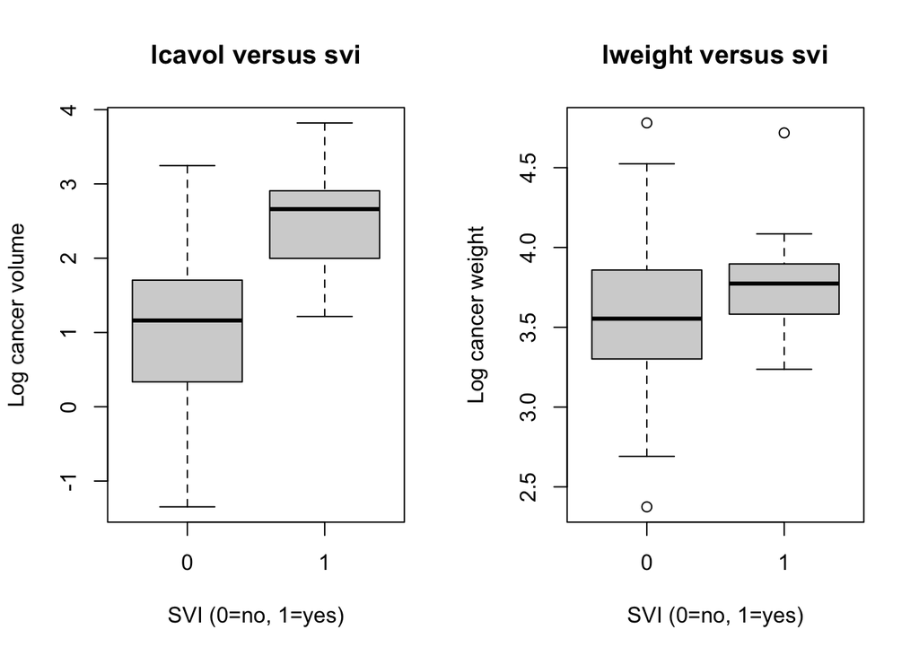

```r
pros.df$svi = factor(pros.df$svi)
par(mfrow=c(1,2))
plot(pros.df$svi, pros.df$lcavol, main="lcavol versus svi",
     xlab="SVI (0=no, 1=yes)", ylab="Log cancer volume")
plot(pros.df$svi, pros.df$lweight, main="lweight versus svi",
     xlab="SVI (0=no, 1=yes)", ylab="Log cancer weight")
```

Visually, `lcavol` looks like it has a big difference, but `lweight` perhaps does not

Now let’s try simple two-sample t-tests:

```r
t.test(pros.df$lcavol[pros.df$svi==0],
       pros.df$lcavol[pros.df$svi==1])
```

```
##
##  Welch Two Sample t-test
##
## data:  pros.df$lcavol[pros.df$svi == 0] and pros.df$lcavol[pros.df$svi == 1]
## t = -8.0351, df = 51.172, p-value = 1.251e-10
## alternative hypothesis: true difference in means is not equal to 0
## 95 percent confidence interval:
##  -1.917326 -1.150810
## sample estimates:
## mean of x mean of y
##  1.017892  2.551959
```

```r
t.test(pros.df$lweight[pros.df$svi==0],
       pros.df$lweight[pros.df$svi==1])
```

```
##
##  Welch Two Sample t-test
##
## data:  pros.df$lweight[pros.df$svi == 0] and pros.df$lweight[pros.df$svi == 1]
## t = -1.8266, df = 42.949, p-value = 0.07472
## alternative hypothesis: true difference in means is not equal to 0
## 95 percent confidence interval:
##  -0.33833495  0.01674335
## sample estimates:
## mean of x mean of y
##  3.594131  3.754927
```

Confirms what we saw visually